# Final Portfolio

## Data Description

This data comes from the MGL2506 Microbial Energy at Sea Research Cruise that took place during June and July of 2025. The data set includes CTD data such as salinity, temperature, depth, oxygen, and more of the water column at 33 different stations along the coastline. The data set also includes flow cytometery data from each station at multiple different depths with columns such as cell counts, size, and complexity of autofluorescence and bacterial cells. Nutrient data is also present (nitrate, phosphate, silicate, etc.)

## Data Cleaning

Visualization 2:

Once again the AF groups were summed up to give a total cell count. This was also done with nutrient data (nitrate, phosphate, silicate, nitrite, and ammonium) to get a total sum of the nutrients. I then made a smaller subset of data and only keeping what I needed – station name, depth, autofluorescence sum, and nutrient sum. In this part I made sure they were all being treated like numbers and removed any missing data. Lastly, I set up a theme that best fit the look I was going for.

## Visualization 1

Figure 1 shows sampling stations along the California coast, where each station is represented by a pie chart. Each slice of the pie shows the relative contribution of different autofluorescent (AF) groups at that station. The overall size of each pie chart reflects the total amount of AF measured there, so larger circles indicate higher overall counts. The map helps show how both the composition and total amount of these groups vary across the locations that were sampled.

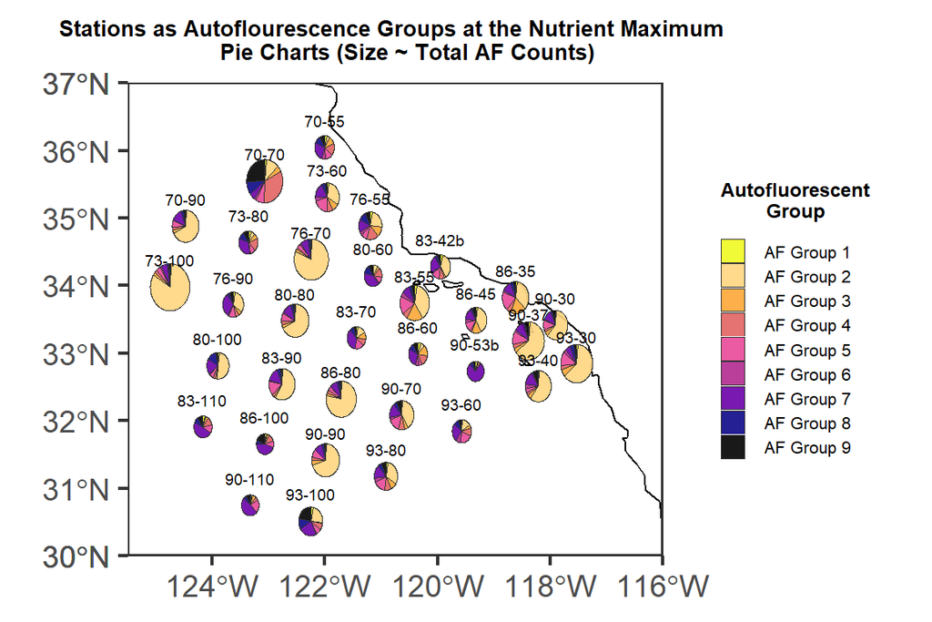

Figure 1. Spatial distribution of autofluorescent (AF) groups at sampling stations along the California coast. Pie charts show the relative composition of nine AF groups at each station, and pie size is scaled to total AF counts.

## Visualization 2

Figure 2 shows how autofluorescence changes in with nutrient levels and depth. The top panel is a scatterplot where each point is a sample. The x-axis shows total nutrients, and the y-axis shows autofluorescence. The color of each point represents how deep the sample was taken. A smooth line runs through the points to show the overall trend. The bottom panel shows a broader view of the same relationship. Instead of individual points, it is a continuous surface that predicts autofluorescence based on nutrient levels and depth. This helps show how autofluorescence varies across both factors at the same time.

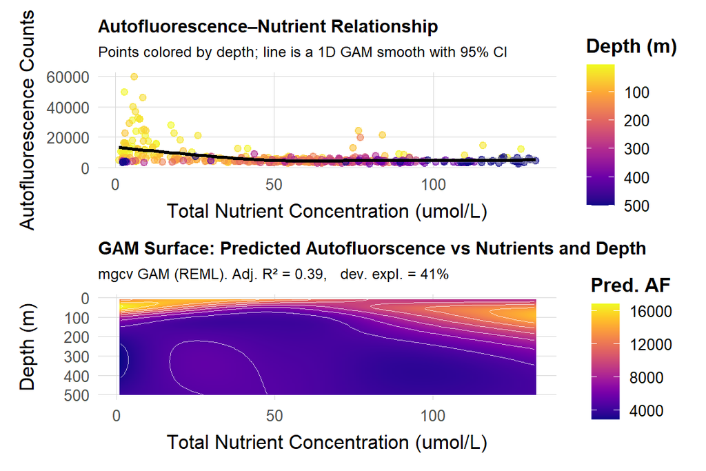

Figure 2. Relationship between autofluorescence, nutrient concentration, and depth. (Top) Scatterplot of autofluorescence versus total nutrients, with points colored by depth and a smoothed trend line. (Bottom) Predicted autofluorescence surface showing combined effects of nutrients and depth.